# Midterm

## Transforming the data (15 points)

> *If the data needs to be transformed in any way (values recoded, pivoted, etc), do it here. Examples include transforming a continuous variable into a categorical using `case_when()`, etc.*

> *Bonus points (5 points) for datasets that require merging of tables, but only if you reason through whether you should use `left_join`, `inner_join`, or `right_join` on these tables. No credit will be provided if you don’t.*

The colony data set (referring to as left) contains information relating to the percentage of colonies lost, and the stressor data set (referring to as right) contains information to what types of stressors the bee colonies were exposed to. To understand how stressors affect bee colony growth/decline, these two data sets need to be merged. These data sets can be linked by the following variables: year, months, state. A left_join will be used for this analysis because we want to retain all records relating to bee colony populations; however, stressor data without a corresponding bee colony population is not useful for this analysis and should be removed.

```r
#merge colony and stressor
bee <- left_join(colony, stressor,
    by = c("year" = "year", "months" = "months", "state" = "state")) %>% glimpse() #check merge as expected
```

```
## Rows: 7,332
## Columns: 14
## $ X.x             <int> 1, 1, 1, 1, 1, 1, 2, 2, 2, 2, 2, 2, 3, 3, 3, 3, 3, 3, ~
## $ year            <int> 2015, 2015, 2015, 2015, 2015, 2015, 2015, 2015, 2015, ~
## $ months          <chr> "January-March", "January-March", "January-March", "Ja~
## $ state           <chr> "Alabama", "Alabama", "Alabama", "Alabama", "Alabama",~
## $ colony_n        <dbl> 7000, 7000, 7000, 7000, 7000, 7000, 35000, 35000, 3500~
## $ colony_max      <dbl> 7000, 7000, 7000, 7000, 7000, 7000, 35000, 35000, 3500~
## $ colony_lost     <int> 1800, 1800, 1800, 1800, 1800, 1800, 4600, 4600, 4600, ~
## $ colony_lost_pct <int> 26, 26, 26, 26, 26, 26, 13, 13, 13, 13, 13, 13, 11, 11~
## $ colony_added    <dbl> 2800, 2800, 2800, 2800, 2800, 2800, 3400, 3400, 3400, ~
## $ colony_reno     <dbl> 250, 250, 250, 250, 250, 250, 2100, 2100, 2100, 2100, ~
## $ colony_reno_pct <int> 4, 4, 4, 4, 4, 4, 6, 6, 6, 6, 6, 6, 1, 1, 1, 1, 1, 1, ~
## $ X.y             <int> 1, 2, 3, 4, 5, 6, 7, 8, 9, 10, 11, 12, 13, 14, 15, 16,~
## $ stressor        <chr> "Varroa mites", "Other pests/parasites", "Disesases", ~
## $ stress_pct      <dbl> 10.0, 5.4, NA, 2.2, 9.1, 9.4, 26.9, 20.5, 0.1, NA, 1.8~
```

```r
#prepare data for summarization
 bee_cleaned <- bee %>%
  mutate(
    #convert month bands to quarters
    quarter = case_when(
        months == "January-March" ~ "Q1",
        months == "April-June" ~ "Q2",
        months == "July-September" ~ "Q3",
        months == "October-December" ~ "Q4"
    ),
    yearq = str_c(year, "-", quarter),
    key = str_c(year, "-", quarter, "-", stressor),
    num_col_lost = stress_pct*colony_lost
  ) %>% filter(!is.na(colony_max)) %>% #    filter(!is.na(colony_lost)) %>%
   filter(!is.na(num_col_lost)) %>%
  glimpse() #check transformations as expected
```

```
## Rows: 6,339
## Columns: 18
## $ X.x             <int> 1, 1, 1, 1, 1, 2, 2, 2, 2, 2, 3, 3, 3, 3, 3, 3, 4, 4, ~
## $ year            <int> 2015, 2015, 2015, 2015, 2015, 2015, 2015, 2015, 2015, ~
## $ months          <chr> "January-March", "January-March", "January-March", "Ja~
## $ state           <chr> "Alabama", "Alabama", "Alabama", "Alabama", "Alabama",~
## $ colony_n        <dbl> 7000, 7000, 7000, 7000, 7000, 35000, 35000, 35000, 350~
## $ colony_max      <dbl> 7000, 7000, 7000, 7000, 7000, 35000, 35000, 35000, 350~
## $ colony_lost     <int> 1800, 1800, 1800, 1800, 1800, 4600, 4600, 4600, 4600, ~
## $ colony_lost_pct <int> 26, 26, 26, 26, 26, 13, 13, 13, 13, 13, 11, 11, 11, 11~
## $ colony_added    <dbl> 2800, 2800, 2800, 2800, 2800, 3400, 3400, 3400, 3400, ~
## $ colony_reno     <dbl> 250, 250, 250, 250, 250, 2100, 2100, 2100, 2100, 2100,~
## $ colony_reno_pct <int> 4, 4, 4, 4, 4, 6, 6, 6, 6, 6, 1, 1, 1, 1, 1, 1, 7, 7, ~
## $ X.y             <int> 1, 2, 4, 5, 6, 7, 8, 9, 11, 12, 13, 14, 15, 16, 17, 18~
## $ stressor        <chr> "Varroa mites", "Other pests/parasites", "Pesticides",~
## $ stress_pct      <dbl> 10.0, 5.4, 2.2, 9.1, 9.4, 26.9, 20.5, 0.1, 1.8, 3.1, 1~
## $ quarter         <chr> "Q1", "Q1", "Q1", "Q1", "Q1", "Q1", "Q1", "Q1", "Q1", ~
## $ yearq           <chr> "2015-Q1", "2015-Q1", "2015-Q1", "2015-Q1", "2015-Q1",~
## $ key             <chr> "2015-Q1-Varroa mites", "2015-Q1-Other pests/parasites~
## $ num_col_lost    <dbl> 18000, 9720, 3960, 16380, 16920, 123740, 94300, 460, 8~
```

> *Show your transformed table here.* Use tools such as `glimpse()`, `skim()` or `head()` to illustrate your point.

```r
#this table shows the merged colony and stressor table with quarter groupings
bee_cleaned %>%
  glimpse() #check transformations as expected
```

```
## Rows: 6,339
## Columns: 18
## $ X.x             <int> 1, 1, 1, 1, 1, 2, 2, 2, 2, 2, 3, 3, 3, 3, 3, 3, 4, 4, ~
## $ year            <int> 2015, 2015, 2015, 2015, 2015, 2015, 2015, 2015, 2015, ~
## $ months          <chr> "January-March", "January-March", "January-March", "Ja~
## $ state           <chr> "Alabama", "Alabama", "Alabama", "Alabama", "Alabama",~
## $ colony_n        <dbl> 7000, 7000, 7000, 7000, 7000, 35000, 35000, 35000, 350~
## $ colony_max      <dbl> 7000, 7000, 7000, 7000, 7000, 35000, 35000, 35000, 350~
## $ colony_lost     <int> 1800, 1800, 1800, 1800, 1800, 4600, 4600, 4600, 4600, ~
## $ colony_lost_pct <int> 26, 26, 26, 26, 26, 13, 13, 13, 13, 13, 11, 11, 11, 11~
## $ colony_added    <dbl> 2800, 2800, 2800, 2800, 2800, 3400, 3400, 3400, 3400, ~
## $ colony_reno     <dbl> 250, 250, 250, 250, 250, 2100, 2100, 2100, 2100, 2100,~
## $ colony_reno_pct <int> 4, 4, 4, 4, 4, 6, 6, 6, 6, 6, 1, 1, 1, 1, 1, 1, 7, 7, ~
## $ X.y             <int> 1, 2, 4, 5, 6, 7, 8, 9, 11, 12, 13, 14, 15, 16, 17, 18~
## $ stressor        <chr> "Varroa mites", "Other pests/parasites", "Pesticides",~
## $ stress_pct      <dbl> 10.0, 5.4, 2.2, 9.1, 9.4, 26.9, 20.5, 0.1, 1.8, 3.1, 1~
## $ quarter         <chr> "Q1", "Q1", "Q1", "Q1", "Q1", "Q1", "Q1", "Q1", "Q1", ~
## $ yearq           <chr> "2015-Q1", "2015-Q1", "2015-Q1", "2015-Q1", "2015-Q1",~
## $ key             <chr> "2015-Q1-Varroa mites", "2015-Q1-Other pests/parasites~
## $ num_col_lost    <dbl> 18000, 9720, 3960, 16380, 16920, 123740, 94300, 460, 8~
```

> *Are the values what you expected for the variables? Why or Why not?*

These data sets are clean. I did not find any unexpected values. However, I did come across NA values, which I removed to complete summary calculations.

## Visualizing and Summarizing the Data (15 points)

> *Use `group_by()` and `summarize()` to make a summary of the data here. The summary should be relevant to your research question*

```r
#summarize dat for question 1: Which stressors result in the largest loss of bee colonies?

ans1 <- bee_cleaned %>%
   group_by(year, stressor) %>% #opting to use year in favor of yearq, after reviewing both versions of visualizations in later step, as yearq crowds the plot and does not add more insight
   summarise(total_sum_lost = sum(num_col_lost)/100000) %>% #dividing by 100,000 to show bee colony loss in 100,000s for ease of viewing
   glimpse()
```

```
## Rows: 42
## Columns: 3
## Groups: year [7]
## $ year           <int> 2015, 2015, 2015, 2015, 2015, 2015, 2016, 2016, 2016, 2~
## $ stressor       <chr> "Disesases", "Other", "Other pests/parasites", "Pestici~
## $ total_sum_lost <dbl> 76.45518, 130.30903, 209.51183, 181.99093, 76.06085, 53~
```

```r
#remove 2021 for quarterly total calculation
bee_cleaned2<-subset(bee_cleaned, year!="2021")

ans2 <- bee_cleaned2 %>%
   group_by(year, quarter) %>%
   summarise(total_sum_lost = sum(num_col_lost)/100000) %>% #dividing by 100,000 to show bee colony loss in 100,000s for ease of viewing
   glimpse()
```

```
## Rows: 23
## Columns: 3
## Groups: year [6]
## $ year           <int> 2015, 2015, 2015, 2015, 2016, 2016, 2016, 2016, 2017, 2~
## $ quarter        <chr> "Q1", "Q2", "Q3", "Q4", "Q1", "Q2", "Q3", "Q4", "Q1", "~
## $ total_sum_lost <dbl> 237.4069, 291.5905, 405.3462, 270.1899, 282.7862, 264.4~
```

> *What are your findings about the summary? Are they what you expected?*

> *Make at least two plots that help you answer your question on the transformed or summarized data. Use scales and/or labels to make each plot informative.*

The figure below plots bee colony loss from the year 2015 to 2021 by stressor. Note that there appears to be a significant drop off in bee population loss in 2021. This is not due to improved bee conservation efforts but, rather, is due to incomplete data for the year 2021.

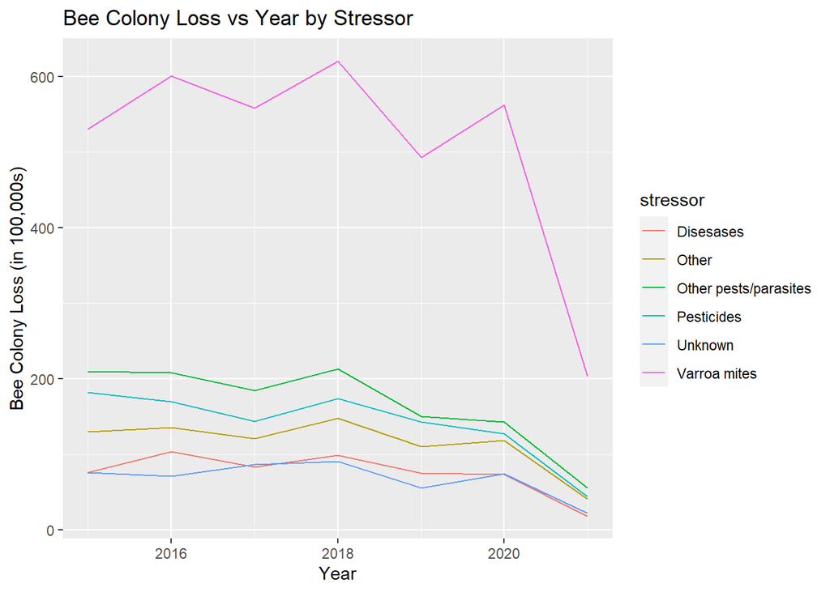

```r
#to answer q1
ggplot(data = ans1) +

  aes(x = year,
      y = total_sum_lost,
      color = stressor) +

  geom_line() +

  labs(title = "Bee Colony Loss vs Year by Stressor",
       x = "Year",
       y = "Bee Colony Loss (in 100,000s)")
```

The figure below is a boxplot of the total number of be colonies lost (in 100,000s) by quarter from the year 2015-2020. Note that the 2021 data have been removed, as they are missing Q3 and Q4.

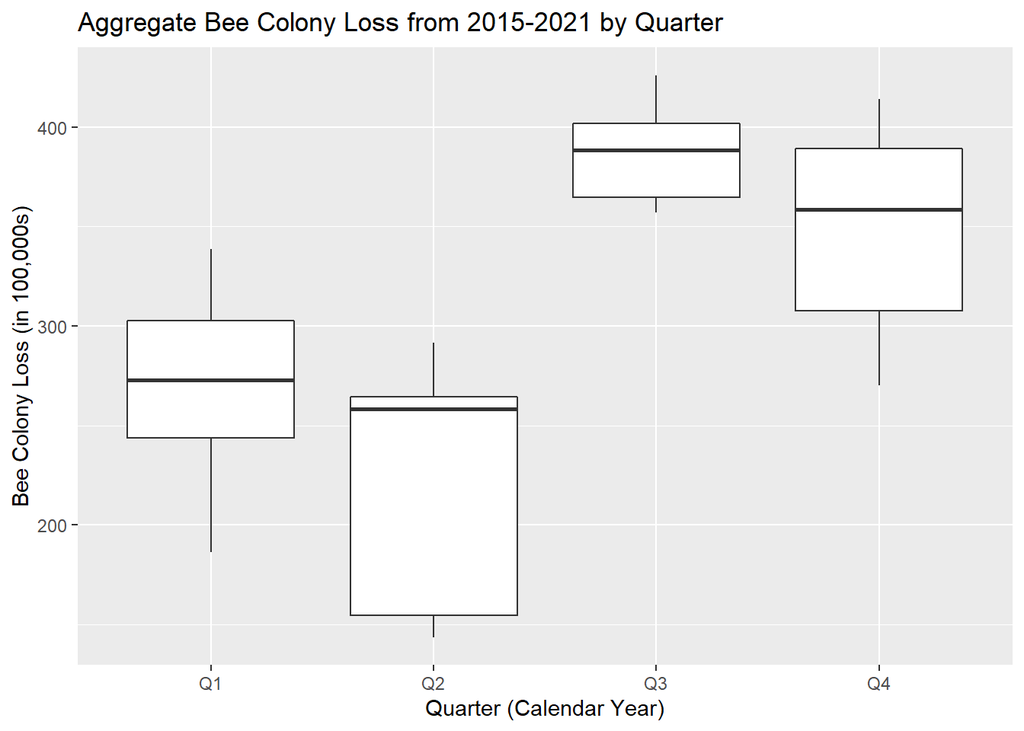

```r
#to answer q2
ggplot(data = ans2) +

  aes(x = quarter,
      y = total_sum_lost,
      color = year) +

  geom_boxplot() +

  labs(title = "Aggregate Bee Colony Loss from 2015-2021 by Quarter",
       x = "Quarter (Calendar Year)",
       y = "Bee Colony Loss (in 100,000s)")
```

## Final Summary (10 points)

> *Summarize your research question and findings below.* *Are your findings what you expected? Why or Why not?*

I was interested in determining which stressor and what time of year result in the highest loss of bee colony populations. I suspected that pesticides were the most harmful stressor and Q4 (October-December) were most detrimental to bee colony populations. However, through my analysis, I found that varro mites were the most harmful stressor, and July through September were the most dangerous months for bees.